# Aligning marine species range data to better serve science and conservation

Casey O’Hara<sup>1</sup>, Jamie C. Afflerbach<sup>1</sup>, Courtney Scarborough<sup>1</sup>, Benjamin S. Halpern<sup>1, 2, 3</sup>

*Author affiliation:*

1. National Center for Ecological Analysis and Synthesis, 735 State Street Suite 300, Santa Barbara CA 93101
2. Bren School of Environmental Science and Management, University of California, Santa Barbara CA 93106
3. Department of Life Sciences, Imperial College London, Silwood Park Campus, Buckhurst Rd, Ascot, West Berkshire SL5 7PY, United Kingdom

*Corresponding author:* Casey O’Hara, National Center for Ecological Analysis and Synthesis, 735 State Street, Suite 300, Santa Barbara CA 93101; (805) 892-2500; ohara@nceas.ucsb.edu

*Classification:* BIOLOGICAL SCIENCES: Sustainability Science

## 0.1 Abstract

*Abstract. Provide an abstract of no more than 250 words on page 2 of the manuscript. Abstracts should explain to the general reader the major contributions of the article. References in the abstract must be cited in full within the abstract itself and cited in the text.*

Species distribution data provide the foundation for a wide range of ecological research studies and conservation management decisions, yet most species ranges remain unknown, and existing range maps often suffer from data limitations and inconsistencies. AquaMaps and the International Union for Conservation of Nature (IUCN) are two distinct efforts to map marine species distributions at a global scale. Together these databases represent 24,637 species (92.9% within AquaMaps, 16.3% within IUCN), with only 2,279 shared species. Here we examine differences in predicted species ranges between the two datasets and find that these misalignments mainly result from divergent methodologies that introduce differing frequencies of commission and omission errors. We illustrate the scientific and management implications of these differences by repeating two recent applications - an assessment of global biodiversity within the Ocean Health Index and a global analysis of gaps in coverage of marine protected areas - and find significantly different results depending on how the two datasets were used. Until a single, highly accurate dataset of global marine species ranges becomes available, understanding the implications of dataset differences for conservation planning and decision-making remains essential.

## 0.2 Significance

*Significance Statement. Authors must submit a 120-word-maximum statement about the significance of their research paper written at a level understandable to an undergraduate-educated scientist outside their field of specialty. The primary goal of the Significance Statement is to explain the relevance of the work in broad context to a broad readership. The Significance Statement appears in the paper itself and is required for all research papers.*

Successful conservation of marine species critically depends on detailed and accurate understanding of where species exist and where they do not. By systematically comparing two widely used global datasets of marine species range maps, we find substantial differences that highlight inconsistencies in our understanding and communication of species ranges. Knowing where and why these inconsistencies occur will substantially improve our ability to develop effective and efficient conservation strategies that support resilient ocean ecosystems.

# 1 Introduction

Knowing where species exist and thrive is fundamental to the sciences of ecology, biogeography, and conservation, among many others. This knowledge provides foundational information for understanding species ranges and diversity, predicting species responses to human impacts and climate change, and managing and protecting species effectively. A rich literature tackles the many dimensions of these questions.

One major outcome of this body of science is the various compiled databases of species distribution maps. Two global-scale repositories predict marine species ranges throughout the world’s oceans – AquaMaps (Kaschner et al. 2013) and International Union for Conservation of Nature (IUCN) (IUCN 2015). These two spatial datasets have been used in hundreds of studies and applications for a wide range of purposes, including assessing marine species status (Halpern et al. 2012, 2015; Selig et al. 2013), evaluating global biodiversity patterns (Coll et al. 2010; Martin et al. 2014, Pimm et al. 2014, Kaschner et al. 2011), predicting range shifts (Molinos et al. 2015), and setting conservation priorities (Klein et al. 2015).

The two datasets ostensibly describe the same information, but significant differences in methodology and intent could lead to dramatically different understandings of our marine ecosystems, with significant implications for policy and conservation recommendations. Importantly, biases in taxonomic or spatial coverage within a dataset could shift management and conservation actions away from places or species that are most in need. Inaccurate indications of presence or absence could lead to ineffective marine reserve systems and management plans (Rondinini et al. 2006, Jetz et al. 2008).

To understand the implications of differences between the AquaMaps and IUCN datasets, we compare how each data source represents the global spatial and taxonomic distribution of species. Most notably, AquaMaps includes range maps for many more species (currently 22,889 species; 92.9% of total), such that most global analyses related to biodiversity to date have used AquaMaps (IUCN range map data exist for only 4,027 unique marine species). For the 2,279 species (9.3% of total) mapped in both datasets, we examine how well the maps align, determine several issues that lead to misalignment between predicted species distributions, and outline possible improvements.

We then reexamine two recent marine biodiversity studies - an assessment of the status of global biodiversity within the Ocean Health Index (Halpern et al. 2012, 2015) and a global analysis of gaps in protection afforded by marine protected areas (MPAs) (Klein et al. 2015) - as case studies to explore the implications of prioritizing one data set over the other. The results highlight possible consequences of different data use decisions on our understanding of marine biodiversity status and protection.

# 2 Results and Discussion

## 2.1 How and why the datasets differ

The IUCN publishes species range maps based on expert input of spatial boundaries of a given species’ “limits of distribution” (IUCN 2015) - essentially a refined extent of occurrence, based on observation records and informed by expert understanding of species’ range and habitat preferences. In contrast, AquaMaps models species distribution based on environmental preferences (e.g., temperature, depth, salinity) deduced from occurrence records, published species databases such as FishBase, and expert knowledge. The AquaMaps model overlays these environmental preferences atop a map of environmental attributes on a 0.5 degree grid, creating a global raster of “probability of occurrence” for each species (Kaschner et al. 2006, Ready et al. 2010). Studies frequently define “presence” for AquaMaps by applying a probability threshold, e.g., the Ocean Health Index defines presence as 40% or greater probability of occurrence (Halpern et al. 2012, 2015).

The methodologies behind the creation of these datasets imply differences in prediction of species distribution due to errors of commission (falsely indicating species presence) and omission (falsely indicating species absence). Geographic range data such as IUCN range maps frequently introduce commission errors, while species distribution models such as AquaMaps will likely introduce fewer commission errors but more omission errors. Each type of error bears different implications for conservation goals: commission errors can result in prioritizing areas not relevant to conservation goals, while omission errors may result in protected area networks that fail to include important habitat and range (Rondinini et al. 2006). By comparing maps resulting from IUCN and AquaMaps methodolog, we can identify and possibly address mechanistic causes for each type of error.

# 3 Implications

Method-driven differences in commission and omission errors drive clear and significant differences in species range descriptions between AquaMaps and IUCN datasets. To examine the implications of these differences, we replicated two recent studies, varying only the prioritization of one data set over the other.

**Case Study: The Ocean Health Index**

The global Ocean Health Index (OHI) (Halpern et al. 2012, 2015), a composite index comprising ten sustainable benefits provided by a healthy ocean, uses species spatial distribution data and IUCN Red List conservation status to calculate biodiversity status (scored from zero to 100) for each of the world’s 221 exclusive economic zones. To maximize the number of represented species, OHI gleans spatial distributions from Red List-assessed species in both IUCN and AquaMaps datasets (n = 7,963), prioritizing IUCN data for the 2,026 species included in both sources. OHI currently uses a probability of occurrence threshold of 40% to determine species presence for AquaMaps data.

**Case Study: MPA Gap Analysis**

Klein et al. (2015) compare the global distribution of species to the global distribution of marine protected areas to assess how well the MPAs protect key species and identify which species fall through gaps in protection. The study relied on the AquaMaps database, using a probability of occurrence threshold of 50% or greater, to determine species presence, and the World Database of Protected Areas to define zones of marine protection. They found that the global MPA network leaves 90.5% of marine species with less than 5% of their overall range represented within MPAs, and 1.4% of species have no protection at all (“gap” species).

We recalculated the amount of under-protected and gap species using either IUCN or AquaMaps data (using 2015 AquaMaps data and a 0% threshold to allow the most meaningful comparison to IUCN’s “limits of distribution”, Fig. 4). We found a five-fold increase in the proportion of gap species (6.4% of species vs. 1.2%) and dramatically larger proportion of species with less than 2% of their range protected (73.2% of species vs. 47.7%). However, this comparison also indicates a larger proportion of well-protected species with greater than 10% of range protected (2.9% of species vs. 1.5%). Conclusions drawn from each of these datasets would paint dramatically different pictures of the protection afforded by our current global MPA network.

# 4 Conclusions

AquaMaps and IUCN range maps show reasonable agreement for many well-studied species, but substantial differences illustrate uncertainty in our understanding of spatial distribution for many others. Although many other appriaches exist for species distribution modeling, these two are the only ones applied globally to marine species. Identifying and addressing differences in these datasets will increase their utility for research and conservation actions. Several likely drivers of commission errors and omission errors between these datasets point to a few important ways to improve range alignment.

Many studies using AquaMaps data test the sensitivity of results by varying the probability of occurrence threshold to determine presence. This decision ultimately represents a tradeoff between errors of commission (low threshold) and omission (high threshold). Using AquaMaps in conjunction with IUCN can mitigate potential errors, while also increasing the taxonomic and spatial breadth of coverage, as long as the differences between the datasets can be reasonably minimized. In this case, we recommend a presence threshold of 0% as it most closely approximates the “limits of distribution” criterion defined by IUCN data providers.

Effective management and protection of marine species depends on a robust understanding of where species exist and where they do not; without this knowledge we risk wasting resources protecting low-value regions while missing opportunities to protect critical ones. By identifying the differences between these two fundamental marine species range datasets and understanding the likely mechanisms causing these discrepancies, we improve our ability to develop strategic and effective conservation policy that supports a resilient ocean ecosystem.

# 5 Methods

**Comparison of taxonomic and regional distribution:** To examine the overall taxonomic distribution across the spatial datasets (Fig. 1), we grouped species by taxonomic class and data source (IUCN, AquaMaps, or both), and examined the proportion of each class represented in each data source category.

**Comparison of paired maps:** Using genus and species binomials as a matching key, we selected the subset of marine species that have range maps in both IUCN and AquaMaps current native distribution. To avoid double-counting, we removed subpopulations and species aliases. We determined species presence within each spatial cell using the same criteria as outlined above.

$\alpha_{dist} = \frac{A_{small \cap large}}{A_{large}} * 100\%$

$\alpha_{area} = \frac{A_{small}}{A_{large}} * 100\%$

**Methods for MPA Gap Analysis case study:** Based upon the methods described in Klein et al. 2015, we reconstructed the analysis using the subset of protected areas (WDPA 2014) spatially covering a marine area and classified as IUCN I-IV. The WDPA polygons and marine polygons were rasterized to 0.01° and then aggregated to AquaMaps native 0.5° cells, to calculate proportion of protected area and marine within each cell. After verifying our results using the 2014 AquaMaps dataset, we updated the analysis using the 2015 AquaMaps dataset at a presence threshold of 50% (to compare to Klein et al. directly) and 0% (to better compare with IUCN spatial data). To analyze MPA coverage against IUCN spatial data, we extracted IUCN polygon weights per 0.5° cell for each species and compared against the protected area raster. Finally, we combined AquaMaps data (at 0% threshold) and IUCN data, using AquaMaps for the 2,279 overlapping species and again compared against the protected area raster.

# 6 Figures and captions

*still need work on captions; then separate captions from images*

### 6.0.1 Fig. 1

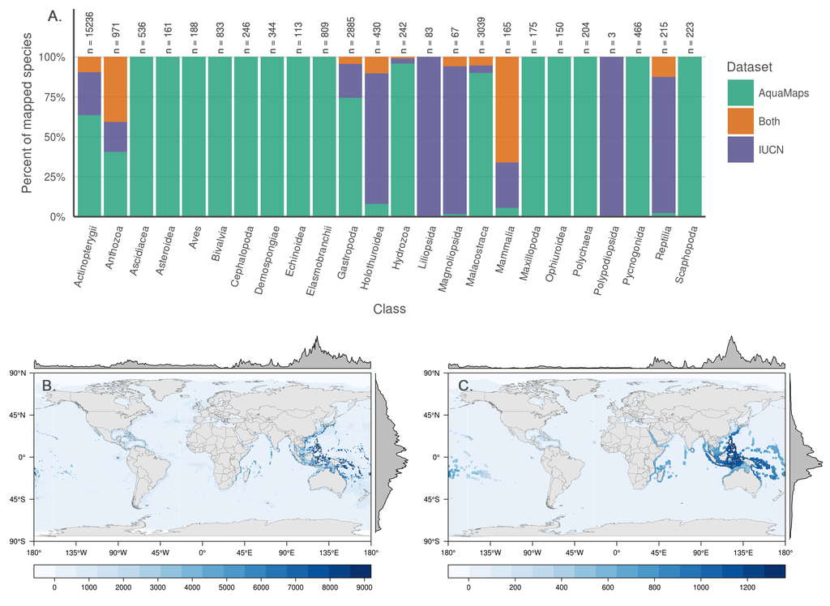

### 6.0.2 Fig. 2

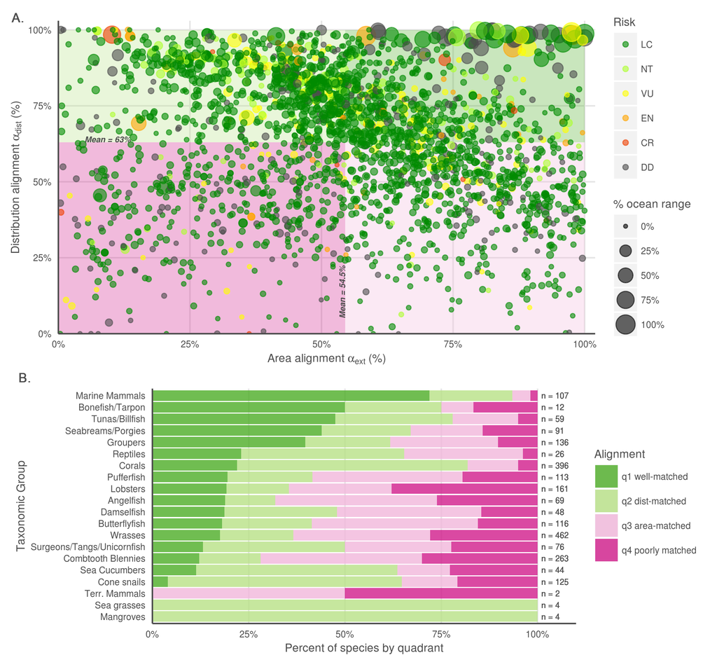

### 6.0.3 Figure 3

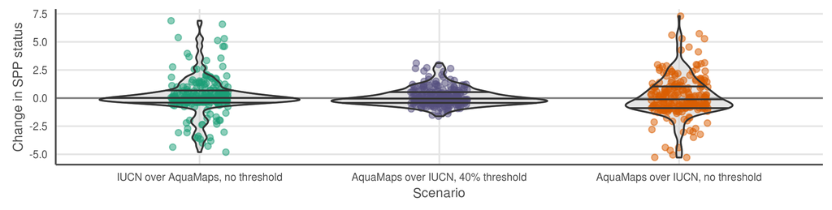

> **Fig. 3.** Change in status score for the Species Subgoal within the global Ocean Health Index under three different scenarios. Scenario 1 shows the effect of reducing the probability threshold to 0% for AquaMaps presence to more accurately track the definition of IUCN “limits of distribution.”  
> Scenario 2 shows the effect of prioritizing AquaMaps data over IUCN, while maintaining the 40% presence threshold. In general, AquaMaps ranges are smaller than IUCN ranges, so most overlapping species will see a decrease in represented range.  
> Scenario 3 shows the effect of prioritizing AquaMaps data over IUCN, and simultaneously eliminating the presence threshold. The zero threshold in scenario 3 drives a decrease in scores relative to scenario 2.

### 6.0.4 Figure 4

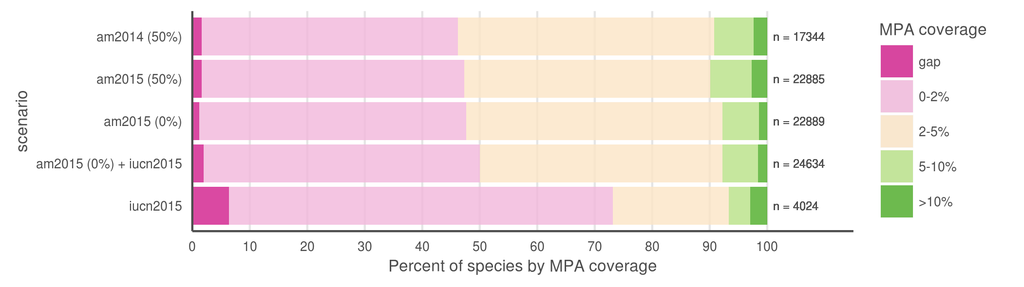

# 7 Acknowledgments

# 8 References

*double check formats; also - include DOIs for references? which if any?*

Kaschner K et al. (2015) AquaMaps: Predicted range maps for aquatic species. World wide web electronic publication, www.aquamaps.org, Version 08/2015. *since this is not a peer-reviewed publication, can we include this for PNAS reference list?*

IUCN (2015). The IUCN Red List of Threatened Species. Version 2015-4. http://www.iucnredlist.org. Downloaded on 21 December 2015. *since this is not a peer-reviewed publication, can we include this for PNAS reference list?*

Halpern BS et al. (2012). An index to assess the health and benefits of the global ocean. Nature, 488(7413), 615-620. _doi:10.1038/nature11397._

Halpern BS et al. (2015). Patterns and emerging trends in global ocean health. PloS one, 10(3), e0117863. *doi?*

Klein CJ et al. (2015). Shortfalls in the global protected area network at representing marine biodiversity. Scientific Reports 5: 17539. _doi:10.1038/srep17539._

Selig ER et al. (2013). Assessing global marine biodiversity status within a coupled socio-ecological perspective. PloS one, 8(4), e60284. _doi:10.1371/journal.pone.0060284._

Coll M et al. (2010). The biodiversity of the Mediterranean Sea: estimates, patterns, and threats. PLoS ONE 5(8): e11842. *used AquaMaps to predict Med biodiversity. Also: Threshold = 0.*

*Martin CS et al. (2014). Manual of marine and coastal datasets of biodiversity importance. May 2014 release. Cambridge (UK): UNEP World Conservation Monitoring Centre. 28 pp. (+ 4 annexes totalling 174 pp. and one e-supplement). *review of marine data sets and data gaps etc, incl both IUCN and AM as well as many others*

Pimm SL et al. (2014). The biodiversity of species and their rates of extinction, distribution, and protection. Science, 344(6187), 1246752. *uses range maps to show biodiversity areas; may use IUCN range maps. Also discusses gaps and possible things that can be done about them.*

Kaschner K, Tittensor DP, Ready J, Gerrodette T, Worm B (2011). Current and Future Patterns of Global Marine Mammal Biodiversity. PLoS ONE 6(5): e19653. *just what the title says - AM development, presence threshold 60%, also analyzes richness as a function of threshold*

Molinos JG et al. (2015). Climate velocity and the future global redistribution of marine biodiversity. Nature Climate Change. _doi:10.1038/nclimate2769._

Rondinini C, Wilson KA, Boitani L, Grantham H, & Possingham HP (2006). Tradeoffs of different types of species occurrence data for use in systematic conservation planning. Ecology letters, 9(10), 1136-1145. *compares point locality, range maps, and distribution models in terms of omission and commission errors; also outlines Extent of Occurrence and Area of Occupancy distinctions.*

Jetz W, Sekercioglu CH, and Watson JE (2008). Ecological correlates and conservation implications of overestimating species geographic ranges. Conservation Biology, 22(1), 110-119. *EOO maps are usually highly interpolated and overestimate small-scale occurrence, which may bias research outcomes*

Kaschner K, Watson R, Trites AW, Pauly D (2006). Mapping world-wide distributions of marine mammal species using a relative environmental suitability (RES) model. Marine Ecology Progress Series 316: 285–310. *check this citation journal name…* *This outlines the basic RES methodology - AM development*

Ready J et al. (2010). Predicting the distributions of marine organisms at the global scale. Ecological Modelling 221(3): 467-478. *Presents AM; assessing AquaMaps against other presence-only species models*

Spalding MD et al. (2007). Marine ecoregions of the world: a bioregionalization of coastal and shelf areas. BioScience, 57(7), 573-583.

### 8.0.1 Datasets and tools: cite these?

- WDPA IUCN and UNEP-WCMC (2014). The World Database on Protected Areas (WDPA) [On-line]. Cambridge, UK: UNEP- WCMC. Available at: www.protectedplanet.net [Accessed December 1, 2014].
- R R Core Team (2015). R: A language and environment for statistical computing. R Foundation for Statistical Computing, Vienna, Austria. URL https://www.R-project.org/.
- QGIS QGIS Development Team (2015). QGIS Geographic Information System. Open Source Geospatial Foundation Project. http://qgis.osgeo.org

### 8.0.2 NOT CURRENTLY USED:

Jones MC, Dyeb SR, Pinnegar JK, Cheung WWL (2012). Modelling commercial fish distributions: Prediction and assessment using different approaches. Ecological Modelling 225(2012): 133-145. PDF *comparison of species distribution models including AquaMaps, Maxent and the Sea Around Us Project*

Hurlbert AH, and Jetz W (2007). Species richness, hotspots, and the scale dependence of range maps in ecology and conservation. Proceedings of the National Academy of Sciences, 104(33), 13384-13389. _mostly rasters of range maps? “The scale dependence of range-map accuracy poses clear limitations on braod-scale ecological analyses and conservation assessments. … we provide guidance about the approriate scale of their use_